# Ford GoBike Data Exploration

## by Sarah Abdelkader

## Investigation Overview

The aim of this presentation is to tackle the power of various data visualsation techniques in conveying results of data analysis proces in a readable yet infomrative way.

## Dataset Overview

The dataset used in this study is extracted from "**Ford GoBike**" bike-sharing system.

The raw dataset consists of 183,412 records, each representing s bike trip recorded by Ford Gobike system. Total number of feature which include details about:

Trip Details (Start and End time of each trip, Station Names and unique IDs, Stations' Coordinates) User Details (User Group whether customer or subscriber, User Date of Birth, Gender )

## Different User Groups

This vislualization illustrate the ratio between 2 bike user groups:

- *Subscribers*
- *Customers*

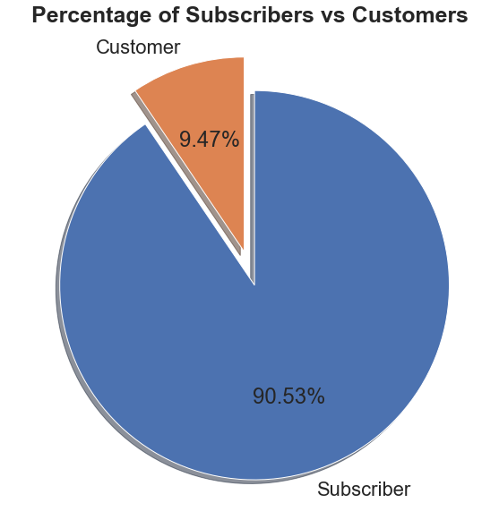

The graph shows that majority of bike users are subscribed to Ford GoBike System.

### Now let's have a look on the distribution of users based on their age.

## Distribution of Users by Age

In this chart, I demontrated the distribution of all bike users by their age, regardless of their subscription type or gender.

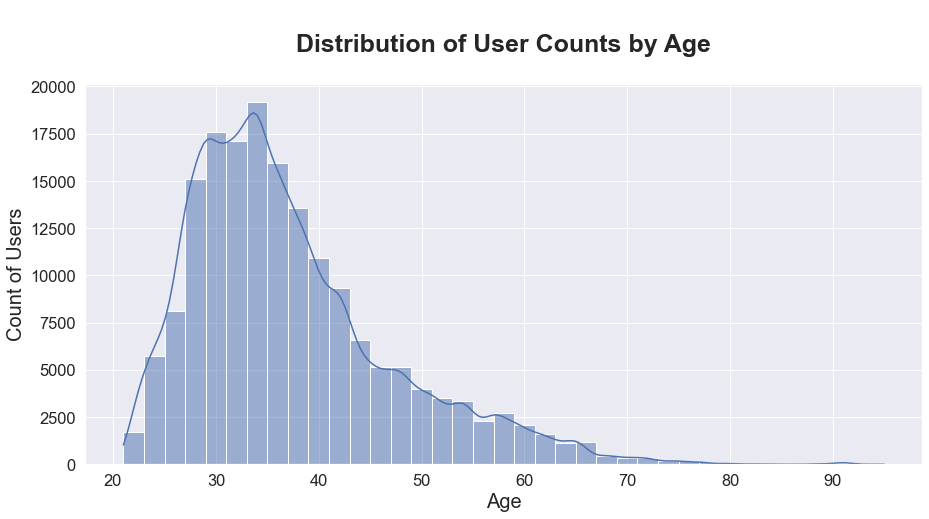

This completely makes sense, since biking is an activity that requires some physical strength.

## Trip Counts Per Hour

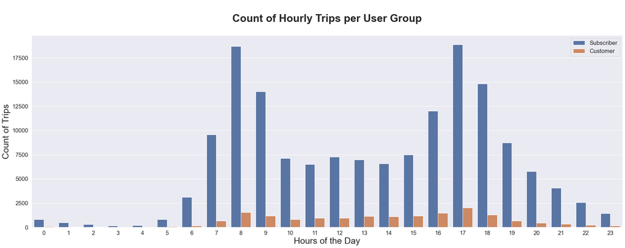

Next chart will emphasize this by taking a closer look on the relation between count of trips on daily basis.

## Trip Counts Per Day

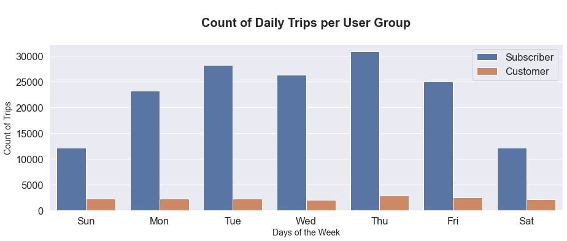

As previously llustrated, we can notice that te highest count of trips on daily basis is recorded on weekdays, whereas the least trips are taken on weekends.

This emphasises the fact: *Majority of Ford Gobike subscribers use the bikes to commute to and from work. On the other hands, customers with no regular subscriptions make low number of trips on daily basis with no noticeable peaks on any specific day.*